# TS_HW1_Liang_Gong

2025-01-17

```r
library(fpp3)
library(dplyr)
```

2.8 Data Set: “Total Private” Employed from us_employment

1. Can you spot any seasonality, cyclicity, and trend?
   - Seasonality: Yes, clear seasonal patterns are visible in the Seasonality Plot and Subseries Plot, where employment shows recurring variations by month.
   - Cyclicity: Possible long-term cycles (e.g., economic recessions or expansions) are visible in the Trend Plot, with dips around 2008 (Great Recession) and during earlier periods.
   - Trend: A strong upward trend is evident in the Trend Plot, with employment steadily increasing over time.
2. What do you learn about the series?
   - The series is strongly seasonal (Seasonality Plot and Subseries Plot).
   - There is high autocorrelation across lags, as shown in the Lag Plot and Autocorrelation Plot, indicating dependence on past values.
   - Employment grows steadily over decades (Trend Plot), with interruptions (e.g., during recessions).
3. What can you say about the seasonal patterns?
   - Employment peaks in summer months (June-July) and dips in winter months (January-February), as shown in the Seasonality Plot and Subseries Plot.
   - These patterns are consistent across years, with little deviation.
4. Can you identify any unusual years?
   - The Trend Plot highlights unusual dips during:
   - 2008–2009 (Great Recession): A significant drop in employment.
   - Other economic events in earlier decades (e.g., around 1983).
   - The Autocorrelation Plot and Seasonality Plot do not indicate unusual disruptions in seasonal patterns during specific years.

These insights suggest a robust seasonal and upward employment trend, with some years standing out due to major economic downturns.

```r
# “Total Private” Employed from us_employment
# Filter the us_employment dataset, keeping only rows where the Title column has the value "Total Private". The resulting subset of data is then stored in the us_employment_totalprivate variable.
head(us_employment)
```

```
## # A tsibble: 6 x 4 [1M]
## # Key:       Series_ID [1]
##      Month Series_ID     Title         Employed
##      <mth> <chr>         <chr>            <dbl>
## 1 1939 Jan CEU0500000001 Total Private    25338
## 2 1939 Feb CEU0500000001 Total Private    25447
## 3 1939 Mar CEU0500000001 Total Private    25833
## 4 1939 Apr CEU0500000001 Total Private    25801
## 5 1939 May CEU0500000001 Total Private    26113
## 6 1939 Jun CEU0500000001 Total Private    26485
```

```r
us_employment_totalprivate <- us_employment %>% filter(Title == "Total Private")
```

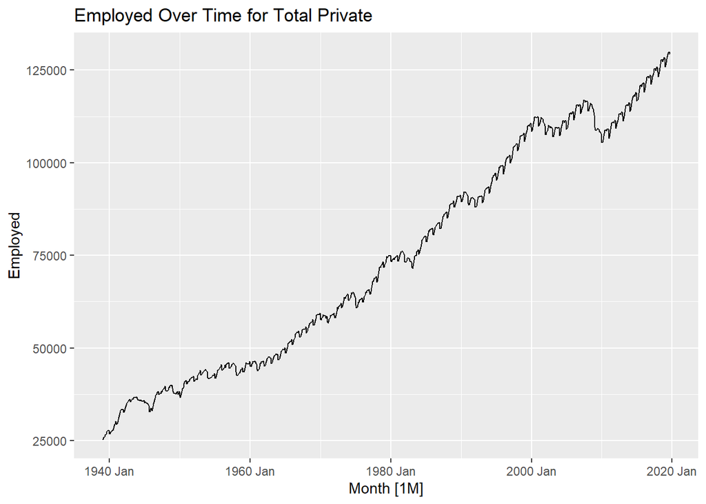

```r
# Use the following graphics functions: autoplot(), gg_season(), gg_subseries(), gg_lag(), ACF() and explore features from us_employment_totalprivate

# 1. autoplot(): Displays the overall trend of Employed over time as a time series plot.
autoplot(us_employment_totalprivate, Employed) + ggtitle("Employed Over Time for Total Private")
```

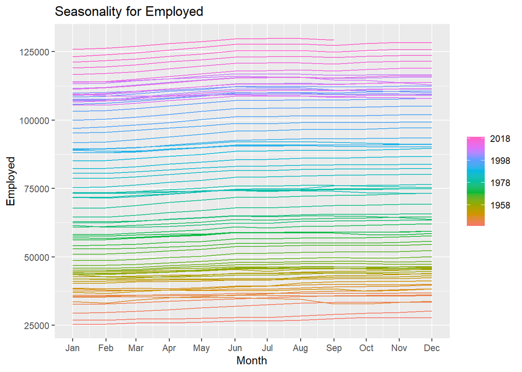

```r
# 2. gg_season(): Highlights recurring seasonal patterns by plotting data points grouped by the time within each seasonal cycle for Employed.
gg_season(us_employment_totalprivate, Employed) + ggtitle("Seasonality for Employed")
```

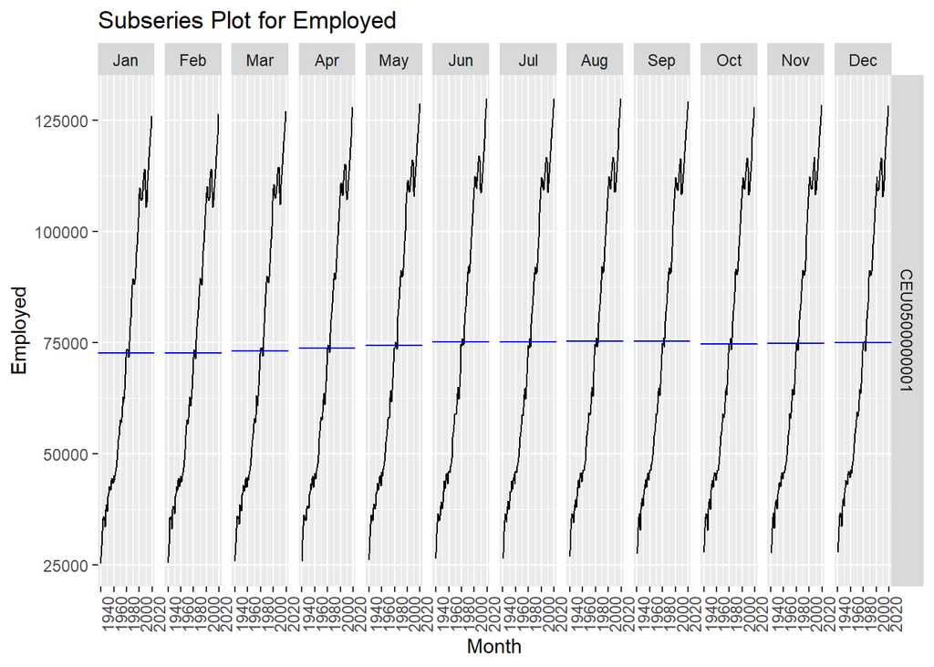

```r
# 3. gg_subseries(): Emphasizes seasonality by showing the average trends for each seasonal period separately for Employed.
gg_subseries(us_employment_totalprivate, Employed) + ggtitle("Subseries Plot for Employed")
```

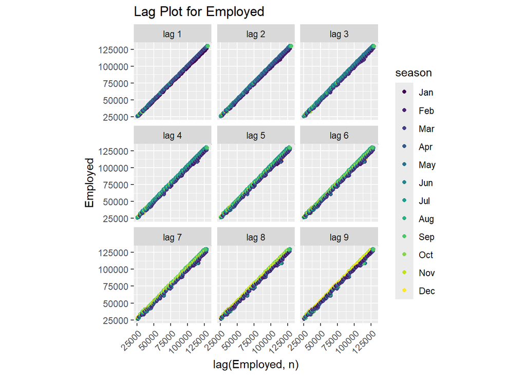

```r
# 4. gg_lag(): Explores relationships between Employed values at different time lags to identify patterns or dependencies.
gg_lag(us_employment_totalprivate, Employed, geom='point') + ggtitle("Lag Plot for Employed") + theme(axis.text.x = element_text(angle = 45, hjust = 1))
```

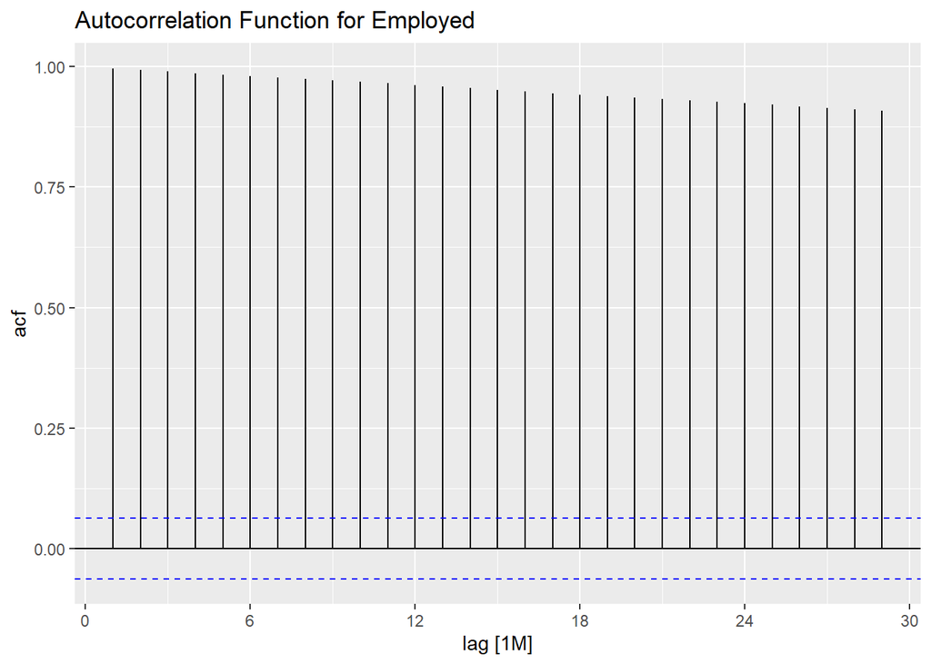

```r
# The strong linear relationships across all lag plots indicate high autocorrelation, meaning the Employed values are strongly dependent on their past values.

# 5. ACF(): Measures and visualizes the correlation between Employed observations at varying time lags.
ACF(us_employment_totalprivate, Employed) %>% autoplot() + ggtitle("Autocorrelation Function for Employed")
```

2.8 Data Set: Bricks from aus_production

1. Can you spot any seasonality, cyclicity, and trend?
   - Seasonality: Yes, seasonal patterns are visible in the Seasonality Plot and Subseries Plot, where production increases in certain quarters (notably Q2 and Q3).
   - Cyclicity: Long-term cycles are visible in the Trend Plot, with production peaking and falling periodically (e.g., peaks in the 1980 and declines in the 1995).
   - Trend: There is an overall rise until the 1980s, followed by a decline in later decades, as shown in the Trend Plot.
2. What do you learn about the series?
   - The series is seasonal and exhibits a strong lagged correlation, as seen in the Seasonality Plot, Subseries Plot, and ACF Plot.
   - There are periods of growth followed by decline, indicating cyclical production behavior.
3. What can you say about the seasonal patterns?
   - Bricks production typically peaks in Q2 and Q3 and dips in Q1, as seen in the Seasonality Plot and Subseries Plot.
   - These seasonal trends are consistent across years.
4. Can you identify any unusual years?
   - The Trend Plot highlights unusual dips around the 1990s, where production declined significantly.
   - Missing or unusual values might explain warnings, and external economic factors are likely linked to periods of disruption, as seen in gaps or sudden changes in some charts.

These charts reveal seasonal, cyclical, and declining trends in brick production over time, with consistent patterns disrupted in specific years like the 1990s.

```r
# Bricks from aus_production
head(aus_production)
```

```
## # A tsibble: 6 x 7 [1Q]
##   Quarter  Beer Tobacco Bricks Cement Electricity   Gas
##     <qtr> <dbl>   <dbl>  <dbl>  <dbl>       <dbl> <dbl>
## 1 1956 Q1   284    5225    189    465        3923     5
## 2 1956 Q2   213    5178    204    532        4436     6
## 3 1956 Q3   227    5297    208    561        4806     7
## 4 1956 Q4   308    5681    197    570        4418     6
## 5 1957 Q1   262    5577    187    529        4339     5
## 6 1957 Q2   228    5651    214    604        4811     7
```

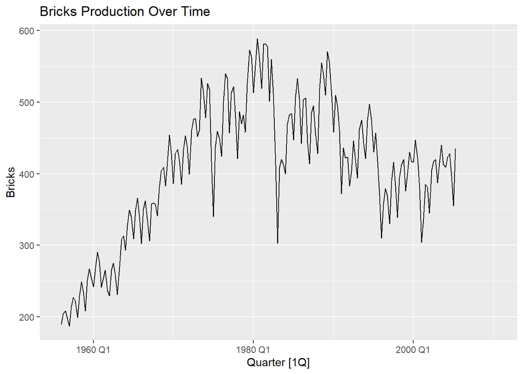

```r
# 1. autoplot()
autoplot(aus_production, Bricks) + ggtitle("Bricks Production Over Time")
```

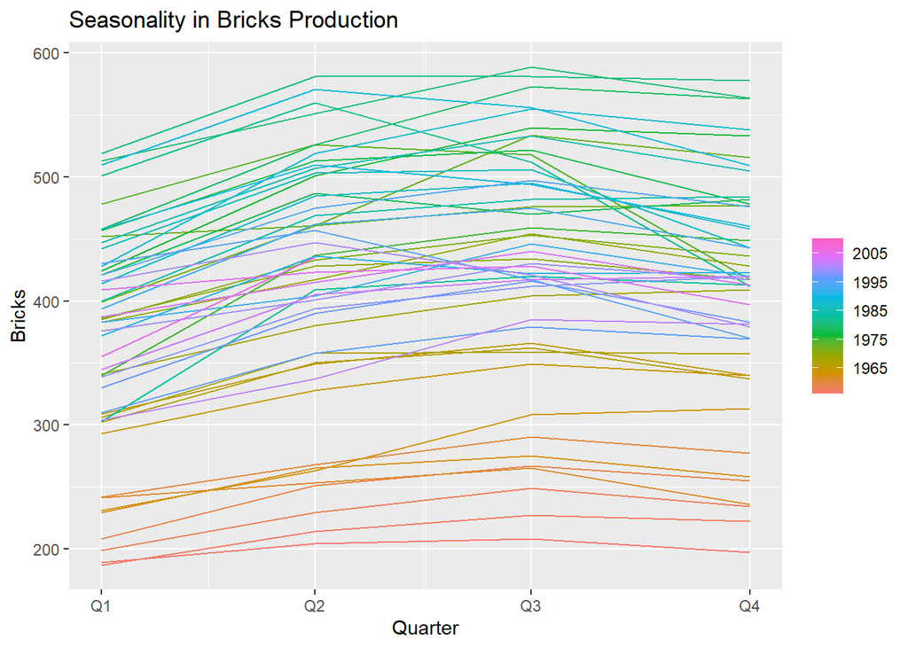

```r
# 2. gg_season
gg_season(aus_production, Bricks) + ggtitle("Seasonality in Bricks Production")
```

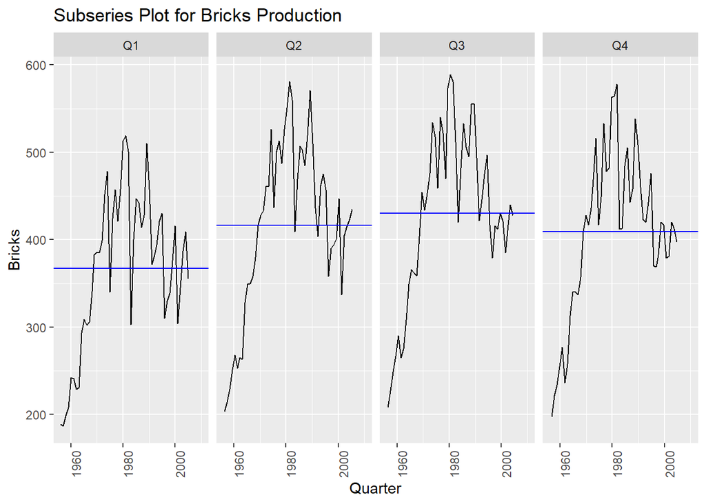

```r
# 3. gg_subseries
gg_subseries(aus_production, Bricks) + ggtitle("Subseries Plot for Bricks Production")
```

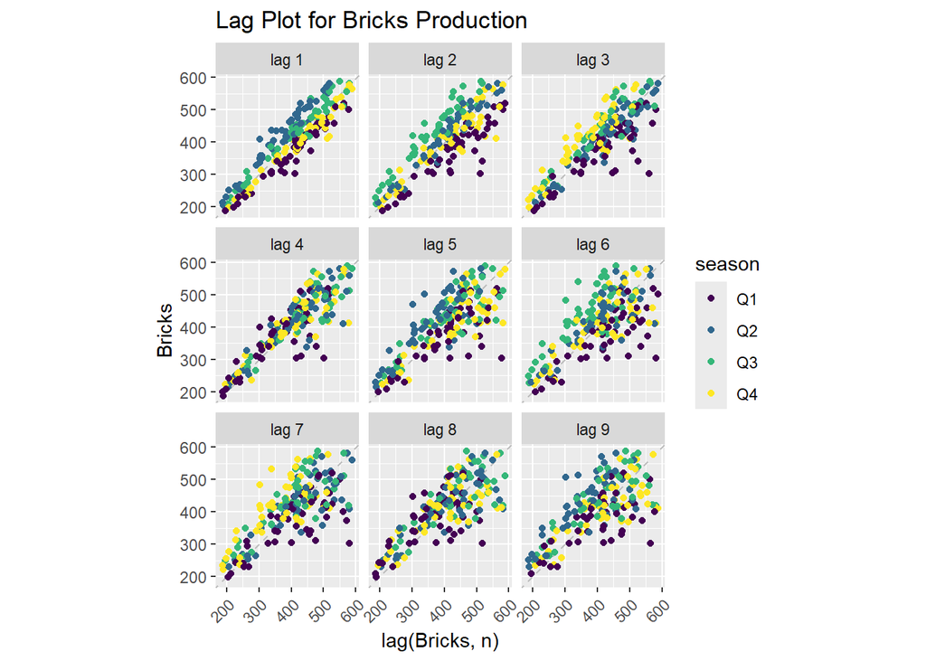

```r
# 4. gg_lag
gg_lag(aus_production, Bricks, geom='point') + ggtitle("Lag Plot for Bricks Production") + theme(axis.text.x = element_text(angle = 45, hjust = 1))
```

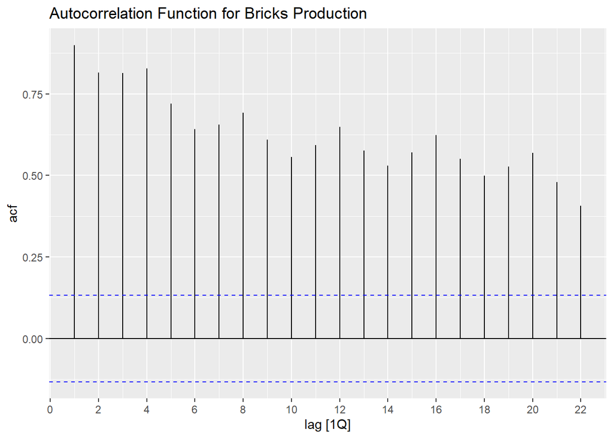

```r
# 5. ACF
ACF(aus_production, Bricks) %>% autoplot() + ggtitle("Autocorrelation Function for Bricks Production")
```

2.8 Data Set: Hare from pelt

1. Can you spot any seasonality, cyclicity, and trend?
   - Seasonality: There is no clear seasonality visible in the charts. In the raw time series chart, the peaks and troughs are not perfectly uniform in height, duration, or spacing. True seasonality typically has a consistent amplitude and periodicity.
   - Cyclicity: Strong cyclic patterns are evident in the Hare Population Over Time chart, showing recurring peaks and troughs approximately every 10 years.
   - Trend: No consistent long-term upward or downward trend is present.
2. What do you learn about the series?
   - The series is highly cyclical, with significant population growth followed by sharp declines, as shown in the Hare Population Over Time chart.
   - The Lag Plot(lag 1) and ACF Plot confirm strong correlations between successive time periods, with distinct periodic lags.
3. What can you say about the seasonal patterns?
   - No strong seasonal patterns are apparent in these charts. The variations are driven more by long-term cycles than regular seasonal fluctuations.
4. Can you identify any unusual years?
   - The Hare Population Over Time chart highlights unusual years with sharp peaks (e.g., around 1865 and 1885) and abrupt declines (e.g., around 1870 and 1880). These may reflect environmental or ecological disruptions affecting hare populations.

```r
# Hare from pelt
head(pelt)
```

```
## # A tsibble: 6 x 3 [1Y]
##    Year  Hare  Lynx
##   <dbl> <dbl> <dbl>
## 1  1845 19580 30090
## 2  1846 19600 45150
## 3  1847 19610 49150
## 4  1848 11990 39520
## 5  1849 28040 21230
## 6  1850 58000  8420
```

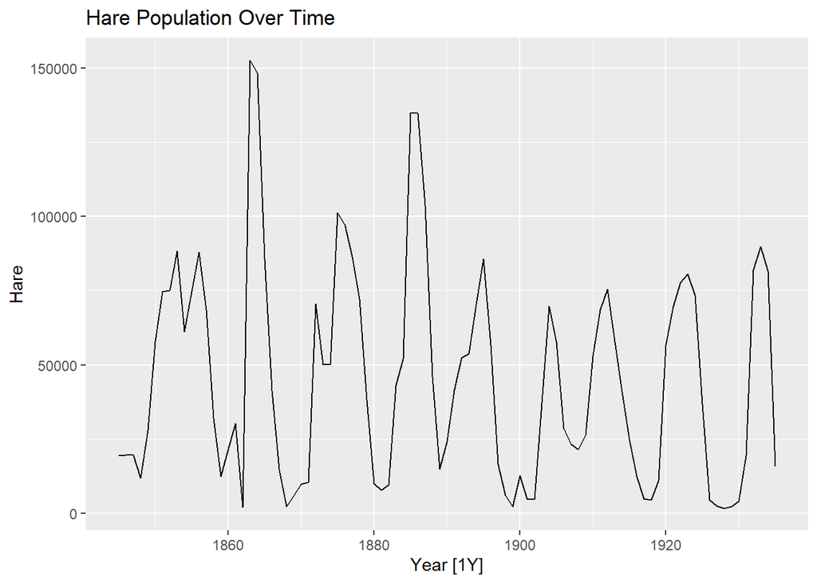

```r
# 1. autoplot()
autoplot(pelt, Hare) + ggtitle("Hare Population Over Time")
```

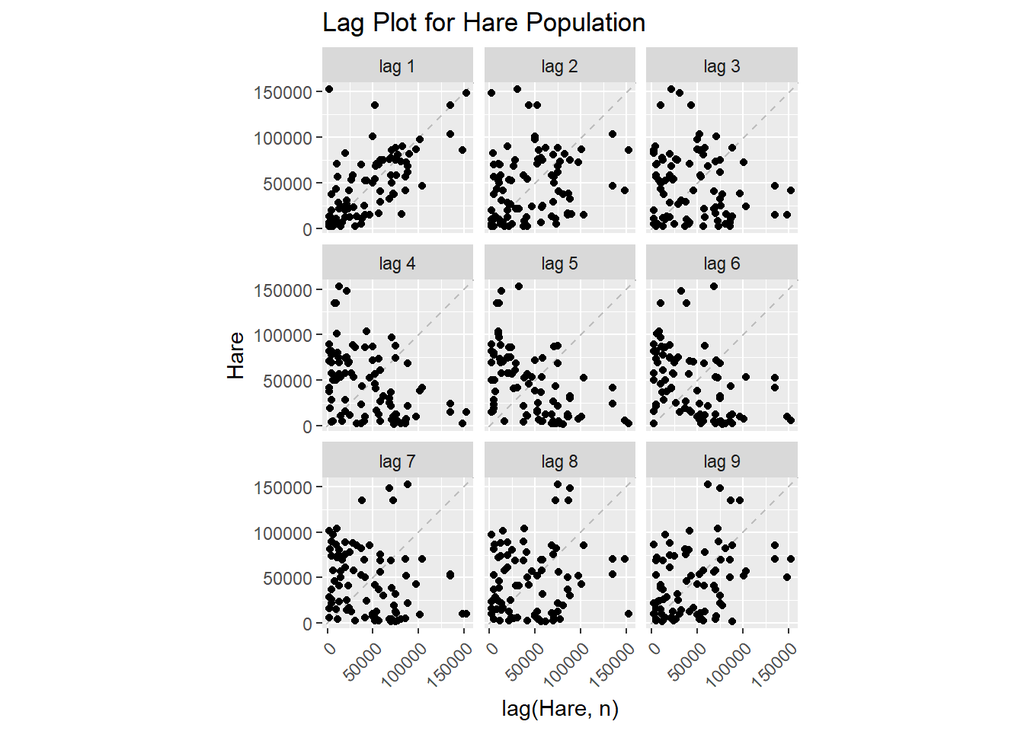

```r
# 2. gg_lag
gg_lag(pelt, Hare, geom='point') + ggtitle("Lag Plot for Hare Population") + theme(axis.text.x = element_text(angle = 45, hjust = 1))
```

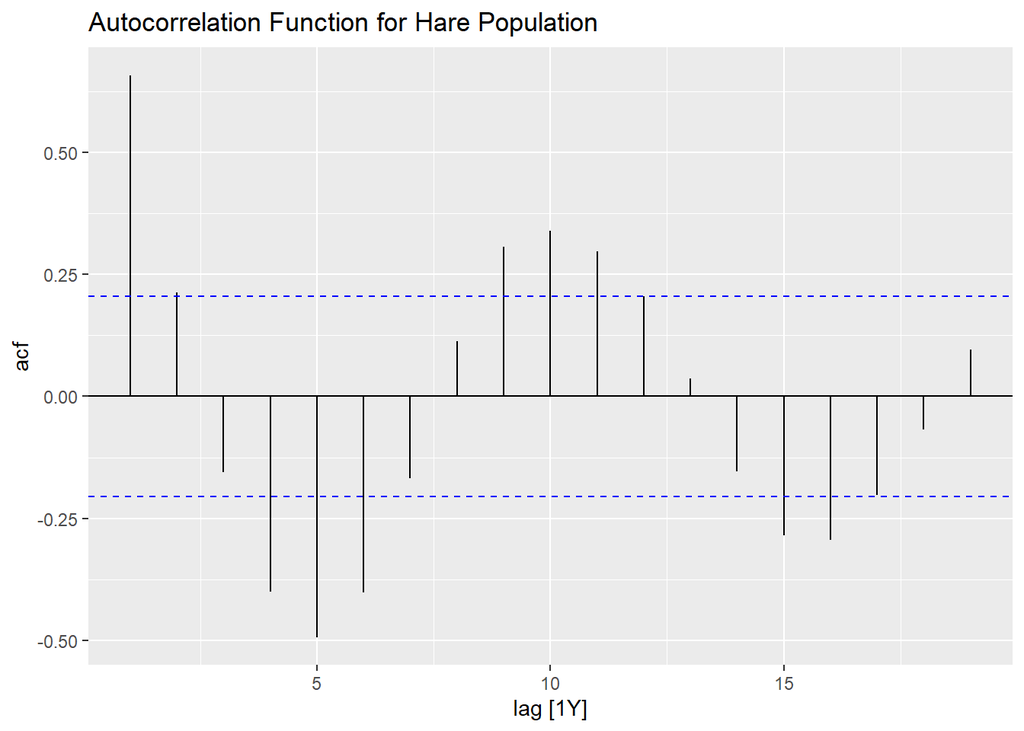

```r
# 3. ACF
ACF(pelt, Hare) %>% autoplot() + ggtitle("Autocorrelation Function for Hare Population")
```

2.8 Data Set: “H02” Cost from PBS

1. Can you spot any seasonality, cyclicity, and trend?
   - Seasonality: Yes, there is clear seasonality, with costs peaking in Oct, Nov, Dec and Jan and dipping in the early months (Feb, Mar, April). This is evident in the Seasonality Plot and Subseries Plot.
   - Cyclicity: There are no clear long-term cycles beyond the seasonal effects.
   - Trend: A steady upward trend is observed over time, as seen in the Cost for H02 Over Time plot.
2. What do you learn about the series?
   - The series exhibits strong seasonal patterns, as shown by recurring peaks and troughs within each year.
   - There is high autocorrelation in the short term, as confirmed by the Lag Plot and Autocorrelation Plot.
   - Costs increase steadily over the years, reflecting growth in usage or pricing.
3. What can you say about the seasonal patterns?
   - Costs consistently peak in Oct, Nov, Dec and Jan and reach their lowest point in February, as highlighted in the Seasonality Plot and Subseries Plot.
   - Seasonal behavior is stable over the years, with little variation in the pattern.
4. Can you identify any unusual years?
   - No clearly unusual years are evident from the charts. However, any deviations from the consistent seasonal pattern would require further inspection of residuals or anomalies.

These charts confirm that the “H02” cost series is characterized by consistent seasonality and an increasing trend over time.

```r
# “H02” Cost from PBS
head(PBS)
```

```
## # A tsibble: 6 x 9 [1M]
## # Key:       Concession, Type, ATC1, ATC2 [1]
##      Month Concession   Type       ATC1  ATC1_desc ATC2  ATC2_desc Scripts  Cost
##      <mth> <chr>        <chr>      <chr> <chr>     <chr> <chr>       <dbl> <dbl>
## 1 1991 Jul Concessional Co-paymen… A     Alimenta… A01   STOMATOL…   18228 67877
## 2 1991 Aug Concessional Co-paymen… A     Alimenta… A01   STOMATOL…   15327 57011
## 3 1991 Sep Concessional Co-paymen… A     Alimenta… A01   STOMATOL…   14775 55020
## 4 1991 Oct Concessional Co-paymen… A     Alimenta… A01   STOMATOL…   15380 57222
## 5 1991 Nov Concessional Co-paymen… A     Alimenta… A01   STOMATOL…   14371 52120
## 6 1991 Dec Concessional Co-paymen… A     Alimenta… A01   STOMATOL…   15028 54299
```

```r
view(PBS)
```

```r
# Identify categorical columns (factors or characters)
categorical_cols <- sapply(PBS, function(col) is.factor(col) || is.character(col))

# Extract distinct values for categorical columns
distinct_values <- lapply(PBS[, categorical_cols, drop = FALSE], unique)

# View results
distinct_values
```

```
## $Concession
## [1] "Concessional" "General"
##
## $Type
## [1] "Co-payments" "Safety net"
##
## $ATC1
##  [1] "A" "B" "C" "D" "G" "H" "J" "L" "M" "N" "P" "R" "S" "V" "Z"
##
## $ATC1_desc
##  [1] "Alimentary tract and metabolism"
##  [2] "Blood and blood forming organs"
##  [3] "Cardiovascular system"
##  [4] NA
##  [5] "Dermatologicals"
```

[output cut: 106 more lines]

```r
# h02_alex <- PBS |>
#   filter(ATC2 == "H02") |>
#   group_by(ATC2) |>
#   summarise(Cost = sum(Cost)) |>
#   ungroup()
```

```r
# # Alex, the TA recommended the h02_alex method, the result is exactly the same as H02_cost below.
# view(h02_alex)
```

```r
# Filter for ATC2 == "H02", group by Month for time series analysis, and calculate the sum of the Cost column.
# Replaces group_by() when working with a tsibble object and grouping by the index column (Month in this case).
# It is designed specifically for time-series data and respects the tsibble structure.
# After using index_by(Month), the summarise() step works as expected, aggregating the Cost column by each unique Month.

H02_cost <- PBS |>
  filter(ATC2 == "H02") |>
  index_by(Month) |>
  summarise(Cost = sum(Cost, na.rm = TRUE))

view(H02_cost)
```

```r
str(H02_cost)       # Check structure of the table
```

```
## tbl_ts [204 × 2] (S3: tbl_ts/tbl_df/tbl/data.frame)
##  $ Month: mth [1:204] 1991 Jul, 1991 Aug, 1991 Sep, 1991 Oct, 1991 Nov, 1991 Dec...
##  $ Cost : num [1:204] 429795 400906 432159 492543 502369 ...
##  - attr(*, "key")= tibble [1 × 1] (S3: tbl_df/tbl/data.frame)
##   ..$ .rows: list<int> [1:1]
##   .. ..$ : int [1:204] 1 2 3 4 5 6 7 8 9 10 ...
##   .. ..@ ptype: int(0)
##  - attr(*, "index")= chr "Month"
##   ..- attr(*, "ordered")= logi TRUE
##  - attr(*, "index2")= chr "Month"
##  - attr(*, "interval")= interval [1:1] 1M
##   ..@ .regular: logi TRUE
```

```r
class(H02_cost$Month)  # Check the class of the Month column
```

```
## [1] "yearmonth"  "vctrs_vctr"
```

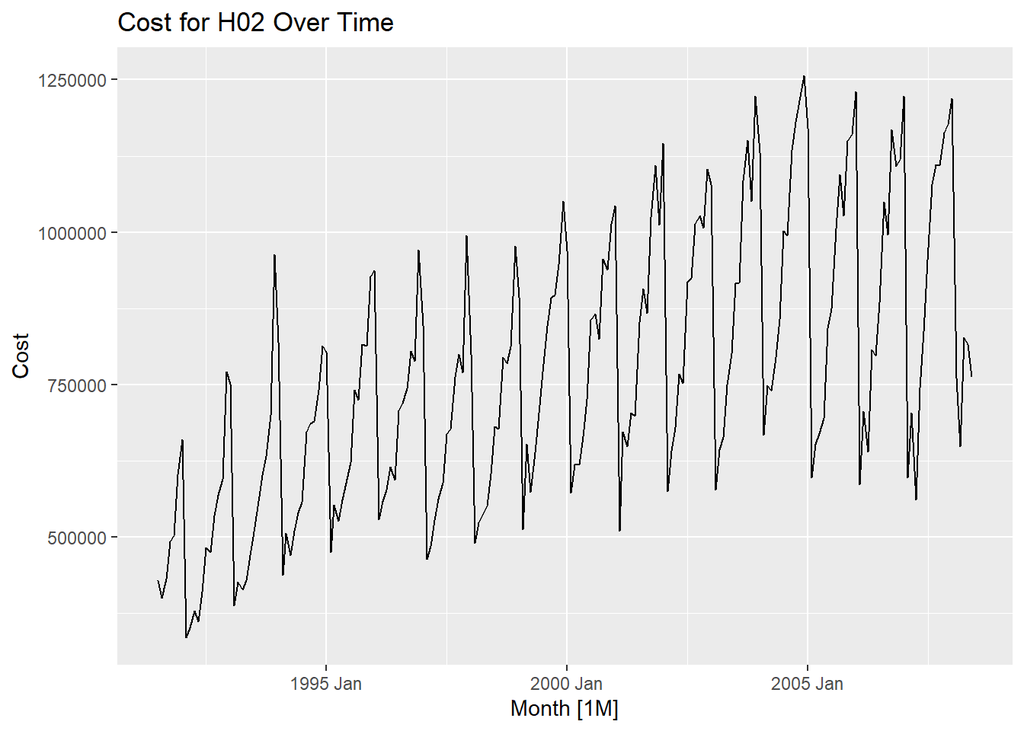

```r
# 1. autoplot
autoplot(H02_cost, Cost) + ggtitle("Cost for H02 Over Time")
```

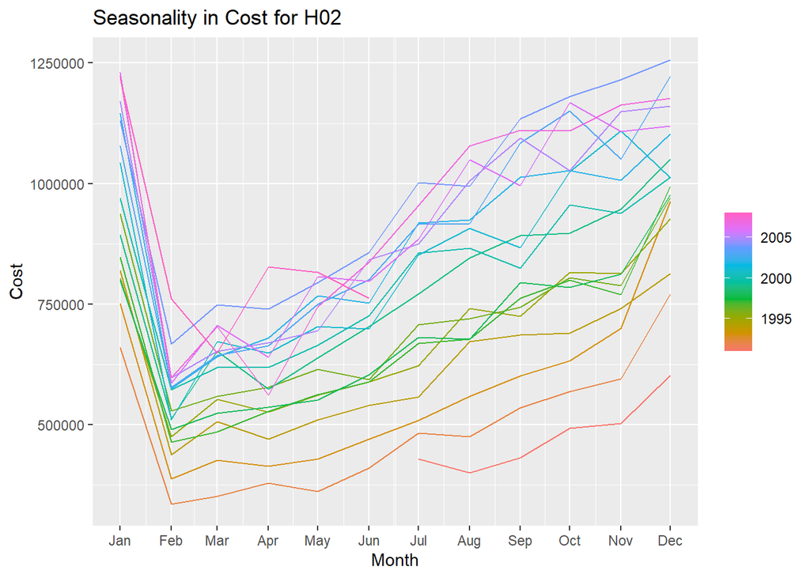

```r
# There are no clear long-term cycles beyond the seasonal effects because the trend plot shows a steady upward increase over time, without recurring multi-year patterns of peaks and troughs typically associated with cyclicity.

# 2. gg_season
gg_season(H02_cost, Cost) + ggtitle("Seasonality in Cost for H02")
```

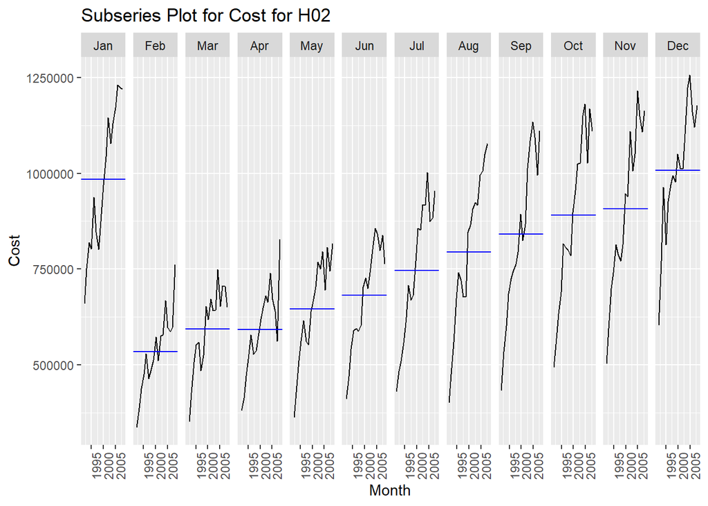

```r
# 3. gg_subseries
gg_subseries(H02_cost, Cost) + ggtitle("Subseries Plot for Cost for H02")
```

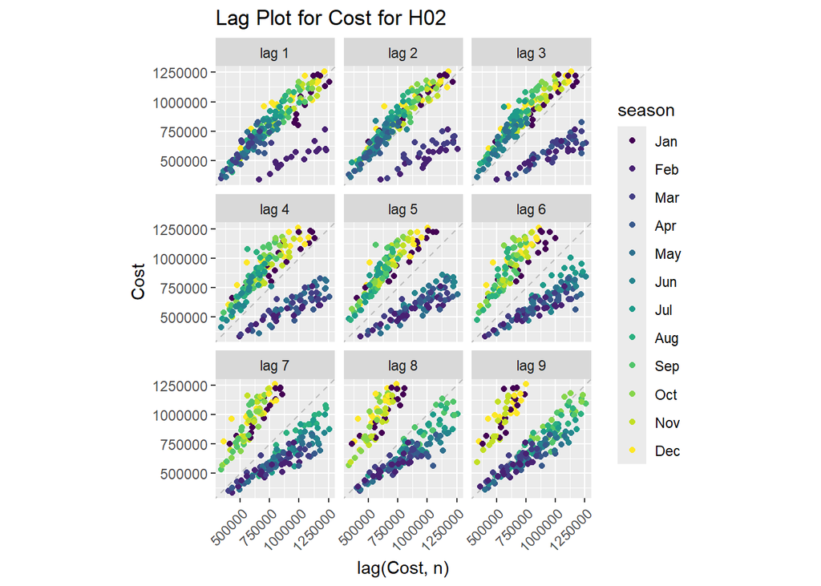

```r
# 4. gg_lag
gg_lag(H02_cost, Cost, geom='point') + ggtitle("Lag Plot for Cost for H02") + theme(axis.text.x = element_text(angle = 45, hjust = 1))
```

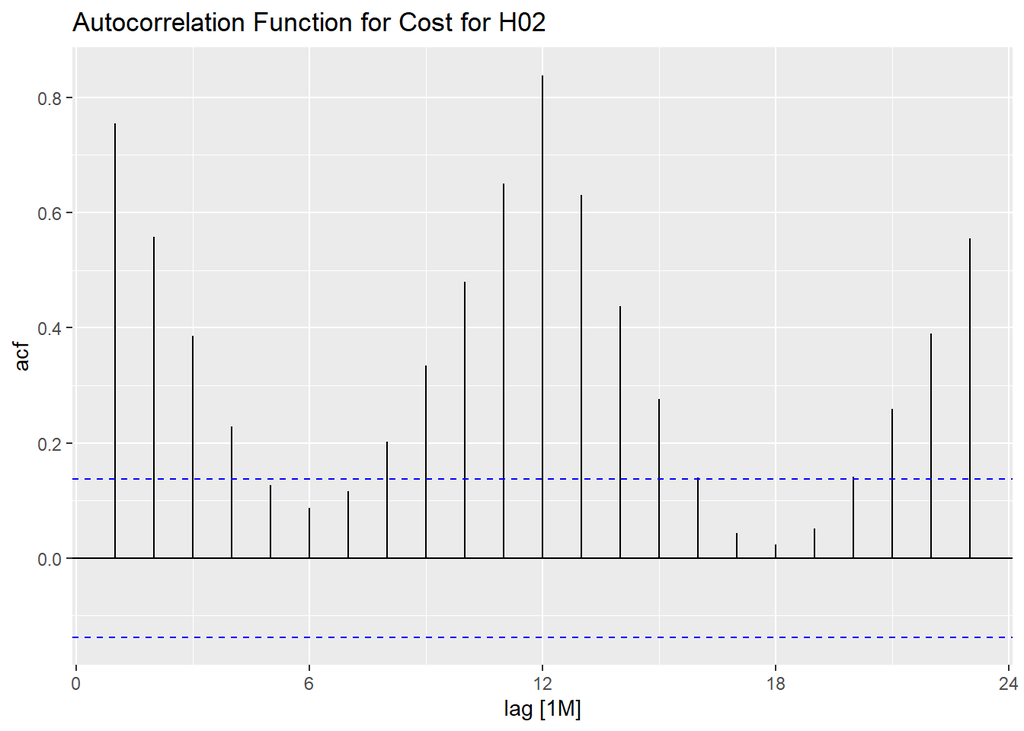

```r
# 5. ACF
ACF(H02_cost, Cost) %>% autoplot() + ggtitle("Autocorrelation Function for Cost for H02")
```

2.8 Data Set: Barrels from us_gasoline

1. Can you spot any seasonality, cyclicity, and trend?
   - Seasonality: Yes, there is clear seasonality with recurring patterns throughout the year, as observed in the Seasonality Plot and Subseries Plot.
   - Cyclicity: There are short-term cycles visible in the plot, most evident in the repeated annual fluctuation.
   - Trend: A gradual upward trend is observed over the years in the Gasoline Barrels Over Time plot, followed by a period of relative stability with some fluctuations.
2. What do you learn about the series?
   - The series shows strong seasonal behavior, where values increase and decrease predictably during specific times of the year.
   - The ACF Plot confirms strong autocorrelation at shorter lags, indicating that past values are good predictors of future ones.
   - The data appears consistent without major anomalies.
3. What can you say about the seasonal patterns?
   - The seasonal patterns are evident, with higher numbers of barrels typically during certain times of the year. This is likely related to seasonal variations in gasoline demand, which can be influenced by travel patterns, weather conditions, and holidays.
   - These patterns are stable across the years, with minimal variation.
4. Can you identify any unusual years?
   - From the Gasoline Barrels Over Time plot, While no year stands out drastically as highly unusual, there may be some volatility in specific years, where demand sharply increases or decreases beyond the typical fluctuations. Some periods (e.g., in the mid-2000s) appear to have particularly sharp rises or falls, which could be due to economic conditions, supply chain disruptions, or other factors.

```r
# Barrels from us_gasoline
head(us_gasoline)
```

```
## # A tsibble: 6 x 2 [1W]
##       Week Barrels
##     <week>   <dbl>
## 1 1991 W06    6.62
## 2 1991 W07    6.43
## 3 1991 W08    6.58
## 4 1991 W09    7.22
## 5 1991 W10    6.88
## 6 1991 W11    6.95
```

```r
view(us_gasoline)
```

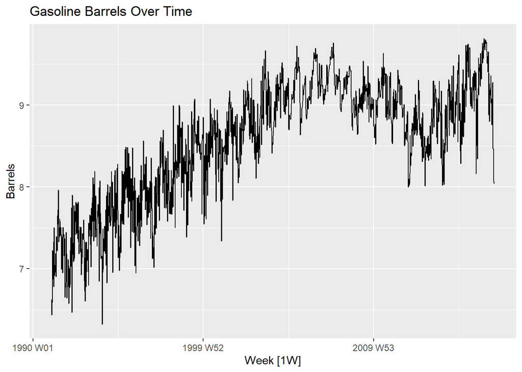

```r
# 1. autoplot
autoplot(us_gasoline, Barrels) + ggtitle("Gasoline Barrels Over Time")
```

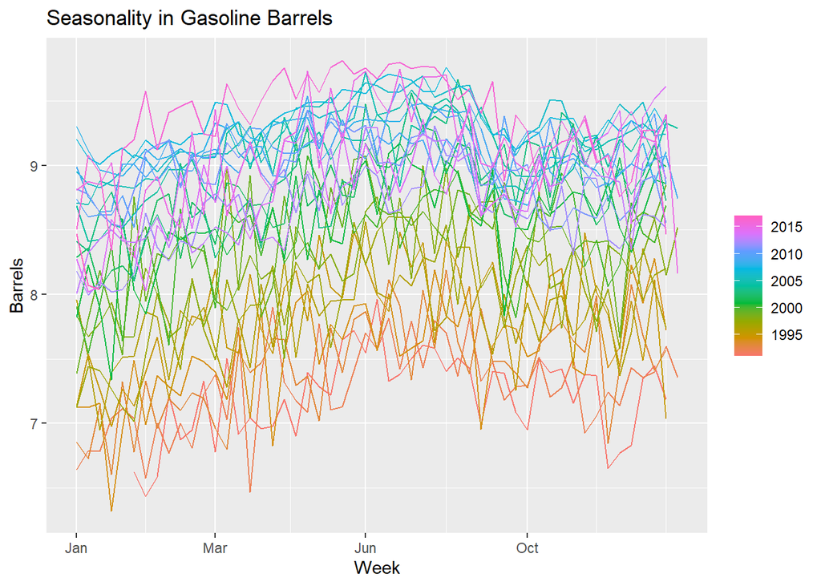

```r
# 2. gg_season
gg_season(us_gasoline, Barrels) + ggtitle("Seasonality in Gasoline Barrels")
```

[figure not shown]

```r
# 3. gg_subseries
gg_subseries(us_gasoline, Barrels) + ggtitle("Subseries Plot for Gasoline Barrels")
```

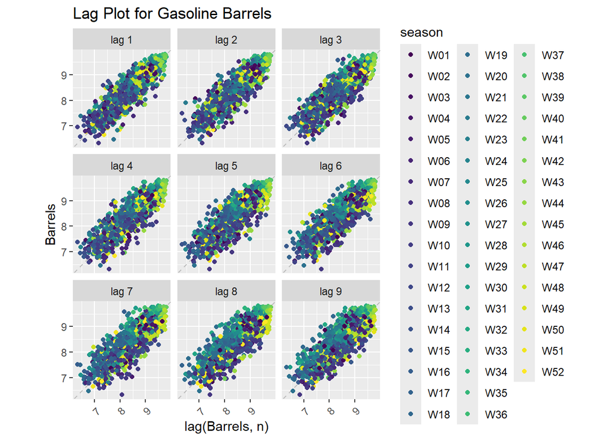

```r
# 4. gg_lag
gg_lag(us_gasoline, Barrels, geom='point') + ggtitle("Lag Plot for Gasoline Barrels") + theme(axis.text.x = element_text(angle = 45, hjust = 1))
```

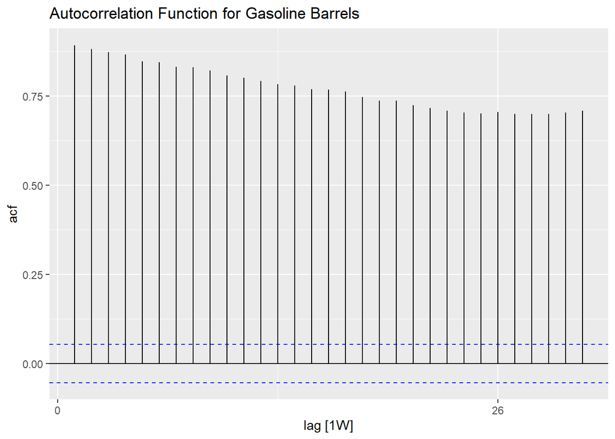

```r
# 5. ACF
ACF(us_gasoline, Barrels) %>% autoplot() + ggtitle("Autocorrelation Function for Gasoline Barrels")
```

7.4 https://otexts.com/fpp3/regression-exercises.html

```r
head(souvenirs)
```

```
## # A tsibble: 6 x 2 [1M]
##      Month Sales
##      <mth> <dbl>
## 1 1987 Jan 1665.
## 2 1987 Feb 2398.
## 3 1987 Mar 2841.
## 4 1987 Apr 3547.
## 5 1987 May 3753.
## 6 1987 Jun 3715.
```

```r
str(souvenirs)
```

```
## tbl_ts [84 × 2] (S3: tbl_ts/tbl_df/tbl/data.frame)
##  $ Month: mth [1:84] 1987 Jan, 1987 Feb, 1987 Mar, 1987 Apr, 1987 May, 1987 Jun,...
##  $ Sales: num [1:84] 1665 2398 2841 3547 3753 ...
##  - attr(*, "key")= tibble [1 × 1] (S3: tbl_df/tbl/data.frame)
##   ..$ .rows: list<int> [1:1]
##   .. ..$ : int [1:84] 1 2 3 4 5 6 7 8 9 10 ...
##   .. ..@ ptype: int(0)
##  - attr(*, "index")= chr "Month"
##   ..- attr(*, "ordered")= logi TRUE
##  - attr(*, "index2")= chr "Month"
##  - attr(*, "interval")= interval [1:1] 1M
##   ..@ .regular: logi TRUE
```

1. Produce a time plot of the data and describe the patterns in the graph. Identify any unusual or unexpected fluctuations in the time series.

Trend: Sales exhibit a clear upward trend over time, suggesting the shop’s growth, likely driven by an expanding customer base, a broader product range, or increased staffing.

Seasonality: Distinct sales spikes occur regularly, especially at the end of the year (Christmas season) and in March (surfing festival), reflecting higher tourist activity during these periods.

Between 1990 and 1991, sales activity appears slightly lower compared to later years, possibly due to slower growth or fewer tourists during that time.

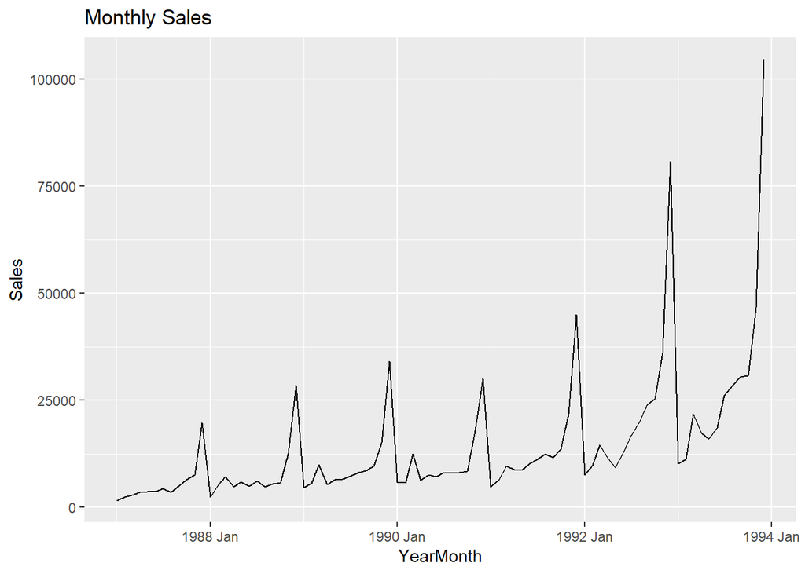

```r
# Produce a time plot of the data
souvenirs %>%
  autoplot(Sales) +
  ggtitle("Monthly Sales") +
  xlab("YearMonth") +
  ylab("Sales")
```

2. Explain why it is necessary to take logarithms of these data before fitting a model.

The souvenirs sales data exhibit increasing variance over time, with more pronounced peaks and a wider spread around them. This phenomenon, known as heteroscedasticity, occurs when the variance of the data changes with the level of the series.

Using a logarithmic transformation stabilizes the variance by compressing higher values more than lower ones, resulting in a more consistent variance across the series. This is important for time series models like ARIMA, which assume constant variance (homoscedasticity).

Additionally, when the data is non-linear, traditional time series models may struggle to fit the data accurately. Log transformation helps make the data more linear, improving model fit and forecasting accuracy.

3. Fit a regression model to the logarithms of these sales data with a linear trend, seasonal dummies and a “surfing festival” dummy variable.

```r
library(lubridate)

# Create the surfing festival dummy variable (for March, using the "yearmonth" class)
souvenirs$SurfingFestival <- ifelse(month(souvenirs$Month) == 3, 1, 0)

# Extract the year and month as separate factors for seasonal dummies
souvenirs$Year <- year(souvenirs$Month)  # Extract year
souvenirs$MonthFactor <- as.factor(month(souvenirs$Month))  # Extract month as a factor
```

```r
head(souvenirs)
```

```
## # A tsibble: 6 x 5 [1M]
##      Month Sales SurfingFestival  Year MonthFactor
##      <mth> <dbl>           <dbl> <dbl> <fct>
## 1 1987 Jan 1665.               0  1987 1
## 2 1987 Feb 2398.               0  1987 2
## 3 1987 Mar 2841.               1  1987 3
## 4 1987 Apr 3547.               0  1987 4
## 5 1987 May 3753.               0  1987 5
## 6 1987 Jun 3715.               0  1987 6
```

```r
# Fit the regression model (log of Sales with linear trend, month factors, and surfing festival)
model <- lm(log(Sales) ~ Year + MonthFactor + SurfingFestival, data = souvenirs)

# Summary of the model
summary(model)
```

```
##
## Call:
## lm(formula = log(Sales) ~ Year + MonthFactor + SurfingFestival,
##     data = souvenirs)
##
## Residuals:
##      Min       1Q   Median       3Q      Max
## -0.41644 -0.12619  0.00608  0.11389  0.38567
##
## Coefficients: (1 not defined because of singularities)
##                   Estimate Std. Error t value Pr(>|t|)
## (Intercept)     -526.30995   20.17321 -26.090  < 2e-16 ***
## Year               0.26872    0.01014  26.508  < 2e-16 ***
## MonthFactor2       0.27344    0.09932   2.753  0.00749 **
## MonthFactor3       0.73999    0.09932   7.450 1.74e-10 ***
## MonthFactor4       0.45011    0.09932   4.532 2.31e-05 ***
## MonthFactor5       0.49757    0.09932   5.010 3.84e-06 ***
## MonthFactor6       0.55893    0.09932   5.627 3.40e-07 ***
## MonthFactor7       0.74257    0.09932   7.476 1.56e-10 ***
## MonthFactor8       0.74210    0.09932   7.472 1.59e-10 ***
## MonthFactor9       0.84549    0.09932   8.512 1.88e-12 ***
## MonthFactor10      0.94557    0.09932   9.520 2.59e-14 ***
## MonthFactor11      1.42695    0.09932  14.367  < 2e-16 ***
## MonthFactor12      2.20446    0.09932  22.195  < 2e-16 ***
## SurfingFestival         NA         NA      NA       NA
## ---
## Signif. codes:  0 '***' 0.001 '**' 0.01 '*' 0.05 '.' 0.1 ' ' 1
##
## Residual standard error: 0.1858 on 71 degrees of freedom
## Multiple R-squared:  0.9527, Adjusted R-squared:  0.9447
## F-statistic: 119.1 on 12 and 71 DF,  p-value: < 2.2e-16
```

```r
# Visualize the fitted model using the autoplot() function and overlay the fitted values
library(ggplot2)
library(broom)  # For augment()

# Augment the model to extract fitted values
# Extracts the fitted values (.fitted) from the lm model for each observation.
# fitted_data: The entire dataframe returned by augment(), which includes the original data, residuals (.resid), fitted values (.fitted)
fitted_data <- augment(model, data = souvenirs)
```

```r
head(fitted_data)
```

```
## # A tibble: 6 × 11
##      Month Sales SurfingFestival  Year MonthFactor .fitted  .resid  .hat .sigma
##      <mth> <dbl>           <dbl> <dbl> <fct>         <dbl>   <dbl> <dbl>  <dbl>
## 1 1987 Jan 1665.               0  1987 1              7.63 -0.211  0.170  0.185
## 2 1987 Feb 2398.               0  1987 2              7.90 -0.119  0.170  0.186
## 3 1987 Mar 2841.               1  1987 3              8.37 -0.416  0.170  0.179
## 4 1987 Apr 3547.               0  1987 4              8.08  0.0956 0.170  0.187
## 5 1987 May 3753.               0  1987 5              8.13  0.104  0.170  0.187
## 6 1987 Jun 3715.               0  1987 6              8.19  0.0329 0.170  0.187
## # ℹ 2 more variables: .cooksd <dbl>, .std.resid <dbl>
```

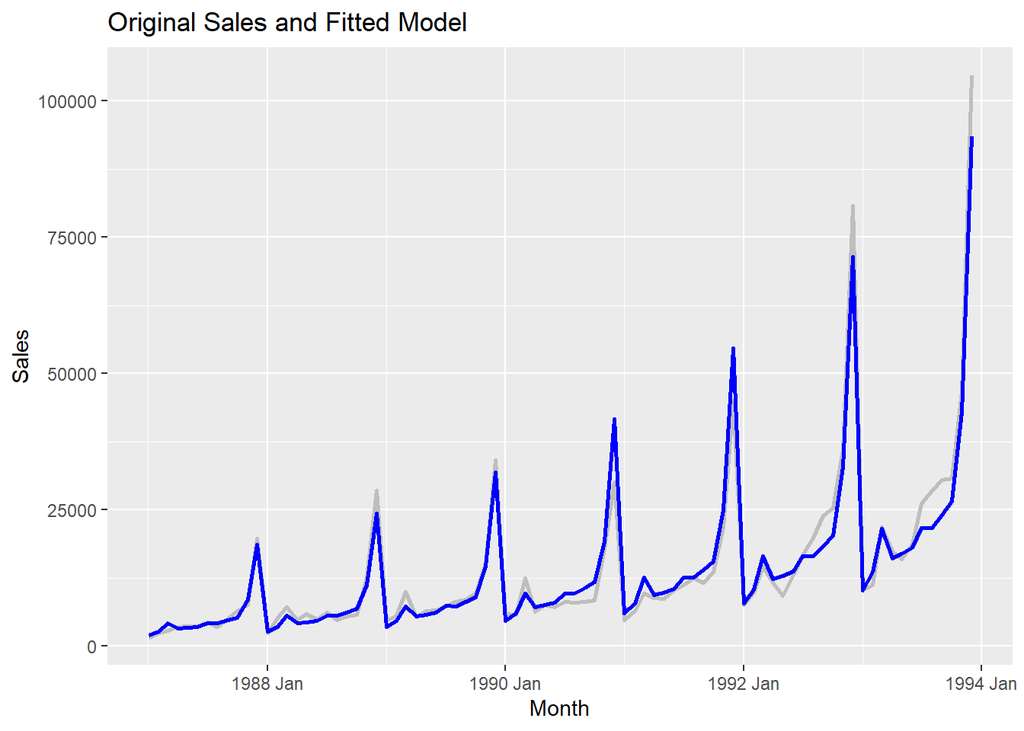

```r
# Plot the original data with the fitted line
ggplot(souvenirs, aes(x = Month, y = Sales)) +
  geom_line(color = "gray", linewidth = 1) +  # Original sales data
  # Adds the fitted values in blue, after transforming the logarithmically fitted values back to the original scale using exp(.fitted).
  geom_line(data = fitted_data, aes(x = Month, y = exp(.fitted)), color = "blue", linewidth = 1) +
  ggtitle("Original Sales and Fitted Model") +
  xlab("Month") +
  ylab("Sales")
```

4. Plot the residuals against time and against the fitted values. Do these plots reveal any problems with the model?

Based on fable approach with TSLM: Issues: Autocorrelation in residuals suggests that the model does not fully account for all time-based dependencies. Some patterns in residuals over time indicate potential missing features, such as additional seasonal components or cycles. No Major Issues: Residuals are roughly normally distributed, and there are no extreme outliers.

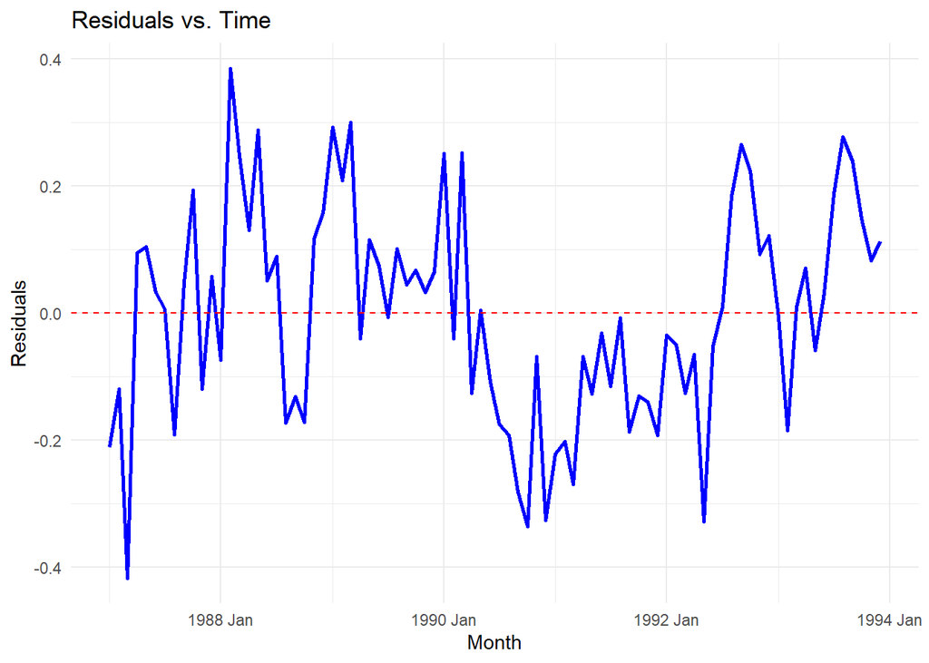

```r
# Plot 1: Residuals vs. Time
ggplot(fitted_data, aes(x = Month, y = .resid)) +
  geom_line(color = "blue", linewidth = 1) +  # Residuals over time
  geom_hline(yintercept = 0, linetype = "dashed", color = "red") +  # Zero reference line
  ggtitle("Residuals vs. Time") +
  xlab("Month") +
  ylab("Residuals") +
  theme_minimal()
```

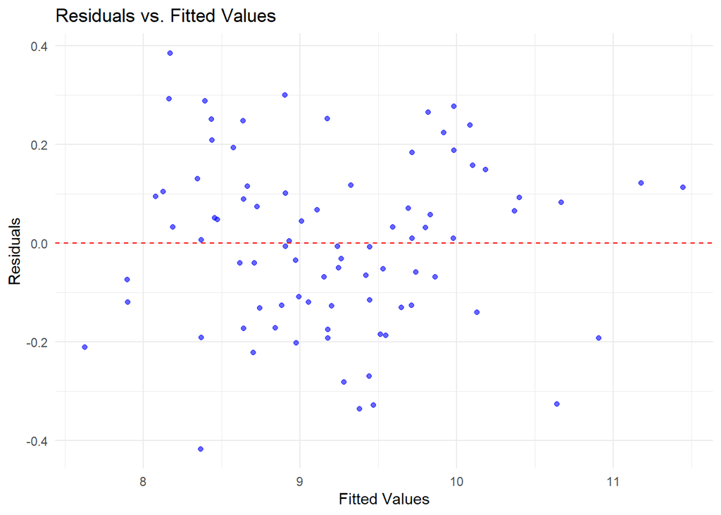

```r
# Plot 2: Residuals vs. Fitted Values
ggplot(fitted_data, aes(x = .fitted, y = .resid)) +
  geom_point(color = "blue", alpha = 0.6) +  # Scatterplot of residuals
  geom_hline(yintercept = 0, linetype = "dashed", color = "red") +  # Zero reference line
  ggtitle("Residuals vs. Fitted Values") +
  xlab("Fitted Values") +
  ylab("Residuals") +
  theme_minimal()
```

Now try fable approach with TSLM

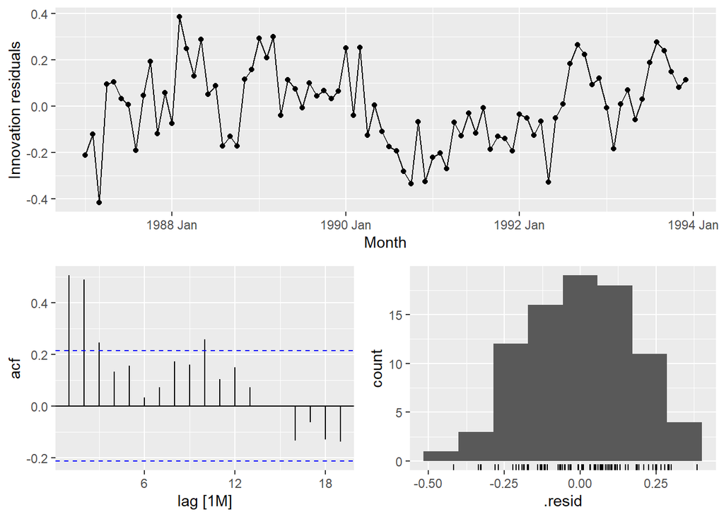

```r
library(tsibble)
library(fable)
library(feasts)

# Ensure souvenirs is a tsibble
# as_tsibble: Converts the data into a tsibble (fable's time series format).
souvenirs_ts <- souvenirs |> as_tsibble(index = Month)

# Fit the model using fable's model function
fitted_model <- souvenirs_ts |>
  model(lm = TSLM(log(Sales) ~ trend() + season() + SurfingFestival))

# Visualize residuals
fitted_model |> gg_tsresiduals()
```

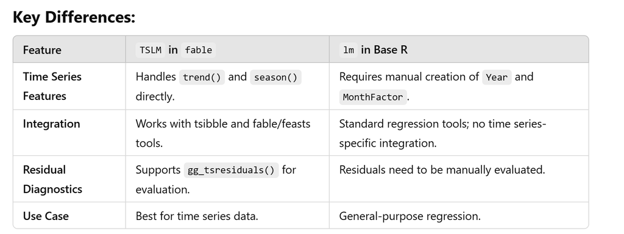

5. Do boxplots of the residuals for each month. Does this reveal any problems with the model?

Seasonal Variability: Residuals for certain months, such as March and August, show greater variability compared to others. This wider spread suggests that the model may not fully account for the seasonal effects during these months.

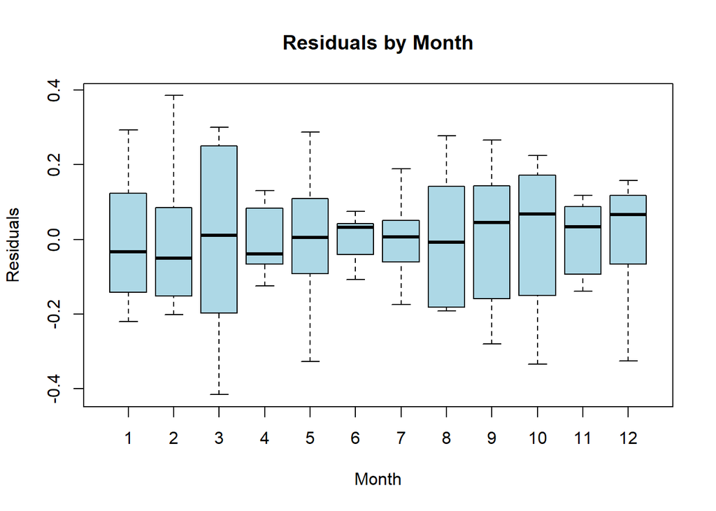

```r
# Create boxplot of residuals by month
boxplot(.resid ~ MonthFactor, data = fitted_data,
        xlab = "Month", ylab = "Residuals",
        main = "Residuals by Month",
        col = "lightblue")
```

6. What do the values of the coefficients tell you about each variable?

Intercept: Value: -526.30995 This represents the baseline log(Sales) when all other predictors (Year and MonthFactor) are zero. Since Year and MonthFactor are not zero-centered in this model, the intercept has limited standalone interpretability in this context.

Year: Value: 0.26872 This indicates that for every one-unit increase in Year (i.e., each additional year), the log(Sales) increases by approximately 0.269. On the original sales scale, this represents exponential growth, with sales increasing by approximately e^0.26872≈1.31 or 31% per year.

MonthFactor: Sales fluctuate significantly across the months. Notably, December has a large positive effect, likely driven by the holiday season. Other months like March (surfing festival month), August, and September also show strong positive effects, indicating seasonality tied to tourism patterns.

SurfingFestival: Value: NA This variable has been excluded due to collinearity with MonthFactor. The effect of the surfing festival (March) is already captured by MonthFactor3.

7. What does the Ljung-Box test tell you about your model?

The Ljung-Box test is utilized to check for autocorrelations at various lag intervals within the residuals of a time series model. This helps to ascertain if the model has fully captured the data’s informational content or if there are still patterns that need to be accounted for. The test sets up two hypotheses: the null hypothesis (H0) posits that there is no autocorrelation up to a certain lag, k, while the alternative hypothesis (H1) suggests that autocorrelation exists up to lag k.

Since the p-value is significantly below 0.05, there is strong evidence to reject the null hypothesis, indicating that the residuals are not independently distributed. This means there is significant autocorrelation in the residuals, suggesting that the model has not fully captured all patterns in the data and may require further improvement.

```r
# Loop over a range of lags (from lag 1 to lag 20)
for (i in 1:20) {
  print(Box.test(residuals(model), type = "Ljung-Box", lag = i))
}
```

```
##
##  Box-Ljung test
##
## data:  residuals(model)
## X-squared = 22.178, df = 1, p-value = 2.484e-06
##
##
##  Box-Ljung test
##
## data:  residuals(model)
## X-squared = 43.233, df = 2, p-value = 4.094e-10
##
##
##  Box-Ljung test
##
## data:  residuals(model)
## X-squared = 48.619, df = 3, p-value = 1.572e-10
##
##
##  Box-Ljung test
##
## data:  residuals(model)
## X-squared = 50.217, df = 4, p-value = 3.254e-10
##
##
##  Box-Ljung test
##
## data:  residuals(model)
## X-squared = 52.448, df = 5, p-value = 4.366e-10
##
##
##  Box-Ljung test
##
## data:  residuals(model)
## X-squared = 52.551, df = 6, p-value = 1.444e-09
##
##
##  Box-Ljung test
##
## data:  residuals(model)
```

[output cut: 64 more lines]

```
##
## data:  residuals(model)
## X-squared = 72.723, df = 18, p-value = 1.556e-08
##
##
##  Box-Ljung test
##
## data:  residuals(model)
## X-squared = 74.832, df = 19, p-value = 1.421e-08
##
##
##  Box-Ljung test
##
## data:  residuals(model)
## X-squared = 75.681, df = 20, p-value = 2.097e-08
```

8. Regardless of your answers to the above questions, use your regression model to predict the monthly sales for 1994, 1995, and 1996. Produce prediction intervals for each of your forecasts.

```r
# Create a new data frame for prediction
# Remove SurfingFestival from your model since its effect is already captured by MonthFactor

# Refit the model excluding SurfingFestival
model <- lm(log(Sales) ~ Year + MonthFactor, data = souvenirs)

# Create a new data frame for prediction
future_data <- data.frame(
  Year = rep(1994:1996, each = 12),
  MonthFactor = as.factor(rep(1:12, times = 3))  # Ensure MonthFactor is a factor
)
```

```r
head(future_data)
```

```
##   Year MonthFactor
## 1 1994           1
## 2 1994           2
## 3 1994           3
## 4 1994           4
## 5 1994           5
## 6 1994           6
```

```r
# Predict sales on the log scale with prediction intervals
predictions <- predict(model, newdata = future_data, interval = "prediction")

# Add predictions back to the future_data frame
future_data <- cbind(future_data, predictions)
```

```r
# Transform predictions back to the original sales scale
future_data <- future_data %>%
  mutate(
    Sales_Predicted = exp(fit),       # Predicted sales
    Lower_Bound = exp(lwr),           # Lower bound of prediction interval
    Upper_Bound = exp(upr)            # Upper bound of prediction interval
  )
```

```r
head(future_data)
```

```
##   Year MonthFactor       fit      lwr       upr Sales_Predicted Lower_Bound
## 1 1994           1  9.509264 9.105002  9.913525        13484.06    9000.202
## 2 1994           2  9.782700 9.378439 10.186962        17724.45   11830.533
## 3 1994           3 10.249256 9.844995 10.653518        28261.51   18863.703
## 4 1994           4  9.959377 9.555115 10.363638        21149.61   14116.722
## 5 1994           5 10.006830 9.602569 10.411091        22177.42   14802.755
## 6 1994           6 10.068191 9.663930 10.472452        23580.87   15739.516
##   Upper_Bound
## 1    20201.76
## 2    26554.69
## 3    42341.27
## 4    31686.25
## 5    33226.11
## 6    35328.75
```

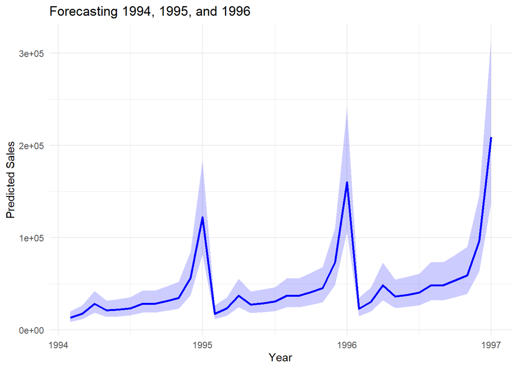

```r
library(ggplot2)

# Plot the predictions with intervals
ggplot(future_data, aes(x = Year + as.numeric(MonthFactor) / 12)) +
  geom_line(aes(y = Sales_Predicted), color = "blue", linewidth = 1) +
  geom_ribbon(aes(ymin = Lower_Bound, ymax = Upper_Bound), fill = "blue", alpha = 0.2) +
  ggtitle("Forecasting 1994, 1995, and 1996") +
  xlab("Year") +
  ylab("Predicted Sales") +
  theme_minimal()
```

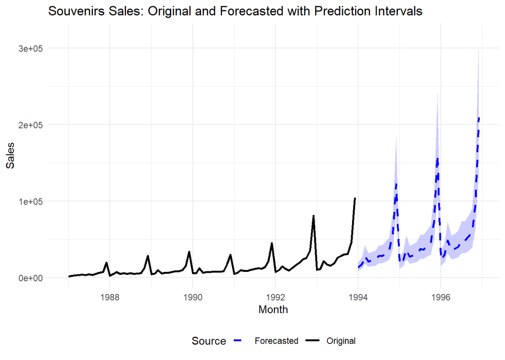

```r
library(ggplot2)

# Combine original and forecasted data
combined_data <- souvenirs %>%
  mutate(Source = "Original") %>%
  select(Month, Sales, Source) %>%
  bind_rows(
    future_data %>%
      mutate(
        Month = as.Date(paste0(Year, "-", MonthFactor, "-01")),
        Sales = Sales_Predicted,
        Source = "Forecasted"
      ) %>%
      select(Month, Sales, Source)
  )

# Plot original sales and forecasted sales with intervals
ggplot() +
  # Original sales data
  geom_line(data = combined_data %>% filter(Source == "Original"),
            aes(x = Month, y = Sales, color = Source), linewidth = 1) +
  # Forecasted sales data
  geom_line(data = combined_data %>% filter(Source == "Forecasted"),
            aes(x = Month, y = Sales, color = Source), linewidth = 1, linetype = "dashed") +
  # Prediction intervals
  geom_ribbon(data = future_data,
              aes(x = as.Date(paste0(Year, "-", MonthFactor, "-01")),
                  ymin = Lower_Bound, ymax = Upper_Bound), fill = "blue", alpha = 0.2) +
  ggtitle("Souvenirs Sales: Original and Forecasted with Prediction Intervals") +
  xlab("Month") +
  ylab("Sales") +
  theme_minimal() +
  scale_color_manual(values = c("Original" = "black", "Forecasted" = "blue")) +
  theme(legend.position = "bottom")
```

```r
head(combined_data)
```

```
## # A tsibble: 6 x 3 [1D]
##   Month      Sales Source
##   <date>     <dbl> <chr>
## 1 1987-01-01 1665. Original
## 2 1987-02-01 2398. Original
## 3 1987-03-01 2841. Original
## 4 1987-04-01 3547. Original
## 5 1987-05-01 3753. Original
## 6 1987-06-01 3715. Original
```

1. How could you improve these predictions by modifying the model?

The Ljung-Box test suggests potential autocorrelation in the residuals, indicating that the current model may not fully capture the time dependencies. To address this, I consider enhancing the model by incorporating an ARIMA (AutoRegressive Integrated Moving Average) component or an ARIMAX model, which includes exogenous variables such as the month and surfing festival dummies.

8.1 https://otexts.com/fpp3/expsmooth-exercises.html

1. Use the ETS() function to estimate the equivalent model for simple exponential smoothing. Find the optimal values of  
   α and ℓ0, and generate forecasts for the next four months.

```r
class(aus_livestock)
```

```
## [1] "tbl_ts"     "tbl_df"     "tbl"        "data.frame"
```

```r
head(aus_livestock)
```

```
## # A tsibble: 6 x 4 [1M]
## # Key:       Animal, State [1]
##      Month Animal                     State                        Count
##      <mth> <fct>                      <fct>                        <dbl>
## 1 1976 Jul Bulls, bullocks and steers Australian Capital Territory  2300
## 2 1976 Aug Bulls, bullocks and steers Australian Capital Territory  2100
## 3 1976 Sep Bulls, bullocks and steers Australian Capital Territory  2100
## 4 1976 Oct Bulls, bullocks and steers Australian Capital Territory  1900
## 5 1976 Nov Bulls, bullocks and steers Australian Capital Territory  2100
## 6 1976 Dec Bulls, bullocks and steers Australian Capital Territory  1800
```

```r
unique(aus_livestock$Animal)
```

```
## [1] Bulls, bullocks and steers Calves
## [3] Cattle (excl. calves)      Cows and heifers
## [5] Lambs                      Pigs
## [7] Sheep
## 7 Levels: Bulls, bullocks and steers Calves ... Sheep
```

```r
# Extract the data for pigs slaughtered in Victoria
pigs <- aus_livestock %>%
  filter(Animal == 'Pigs' & State == 'Victoria')

head(pigs)
```

```
## # A tsibble: 6 x 4 [1M]
## # Key:       Animal, State [1]
##      Month Animal State     Count
##      <mth> <fct>  <fct>     <dbl>
## 1 1972 Jul Pigs   Victoria  94200
## 2 1972 Aug Pigs   Victoria 105700
## 3 1972 Sep Pigs   Victoria  96500
## 4 1972 Oct Pigs   Victoria 117100
## 5 1972 Nov Pigs   Victoria 104600
## 6 1972 Dec Pigs   Victoria 100500
```

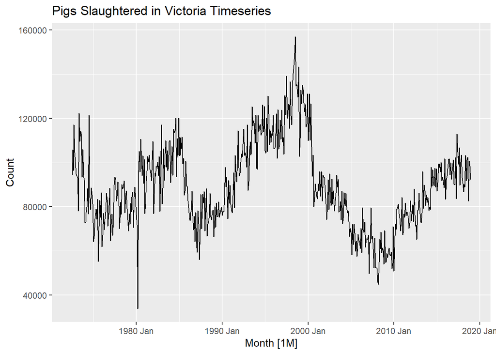

```r
# Plot Time Series of Pigs slaughtered in Victoria
pigs_plot <- pigs %>%
  autoplot(Count) +
  labs(title = 'Pigs Slaughtered in Victoria Timeseries')

pigs_plot
```

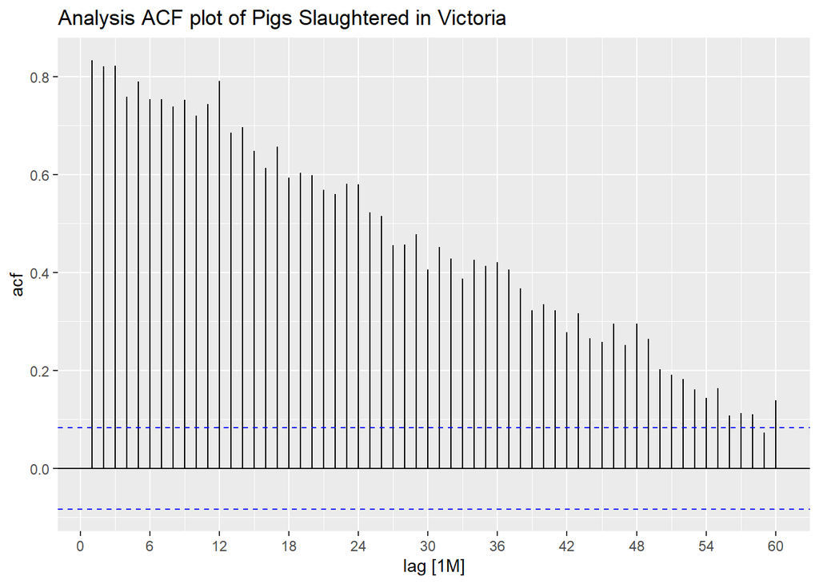

```r
# Plot ACF Plot
pigs |>
ACF (Count, lag_max = 60) |>
autoplot () +
labs (title="Analysis ACF plot of Pigs Slaughtered in Victoria")
```

The analysis of the time series and Autocorrelation Function (ACF) plots, with a lag of 60, indicates that the series shows no clear trend over the period and only minor annual seasonality. This slight seasonality will be ignored as we move forward with using simple exponential smoothing for forecasting.

The forecasting analysis has identified an optimal smoothing constant (α) of 0.3221247 and an initial level (ℓ0) of 100646.6.

```r
# Use the ETS() function to estimate the equivalent model for simple exponential smoothing. Find the optimal values of α and ℓ0
ets_fit <- pigs %>%
  model(ses = ETS(Count ~ error('A') + trend('N') + season('N')))

optimal_values_report <- ets_fit %>% report()
```

```
## Series: Count
## Model: ETS(A,N,N)
##   Smoothing parameters:
##     alpha = 0.3221247
##
##   Initial states:
##      l[0]
##  100646.6
##
##   sigma^2:  87480760
##
##      AIC     AICc      BIC
## 13737.10 13737.14 13750.07
```

```r
augment(ets_fit)
```

```
## # A tsibble: 558 x 8 [1M]
## # Key:       Animal, State, .model [1]
##    Animal State    .model    Month  Count .fitted  .resid  .innov
##    <fct>  <fct>    <chr>     <mth>  <dbl>   <dbl>   <dbl>   <dbl>
##  1 Pigs   Victoria ses    1972 Jul  94200 100647.  -6447.  -6447.
##  2 Pigs   Victoria ses    1972 Aug 105700  98570.   7130.   7130.
##  3 Pigs   Victoria ses    1972 Sep  96500 100867.  -4367.  -4367.
##  4 Pigs   Victoria ses    1972 Oct 117100  99460.  17640.  17640.
##  5 Pigs   Victoria ses    1972 Nov 104600 105142.   -542.   -542.
##  6 Pigs   Victoria ses    1972 Dec 100500 104968.  -4468.  -4468.
##  7 Pigs   Victoria ses    1973 Jan  94700 103529.  -8829.  -8829.
##  8 Pigs   Victoria ses    1973 Feb  93900 100685.  -6785.  -6785.
##  9 Pigs   Victoria ses    1973 Mar  93200  98499.  -5299.  -5299.
## 10 Pigs   Victoria ses    1973 Apr  78000  96792. -18792. -18792.
## # ℹ 548 more rows
```

```r
# Generate forecasts for the next four months based on the data.
fourMonthForcast <- ets_fit %>%
  forecast(h = 4)

fourMonthForcast
```

```
## # A fable: 4 x 6 [1M]
## # Key:     Animal, State, .model [1]
##   Animal State    .model    Month
##   <fct>  <fct>    <chr>     <mth>
## 1 Pigs   Victoria ses    2019 Jan
## 2 Pigs   Victoria ses    2019 Feb
## 3 Pigs   Victoria ses    2019 Mar
## 4 Pigs   Victoria ses    2019 Apr
## # ℹ 2 more variables: Count <dist>, .mean <dbl>
```

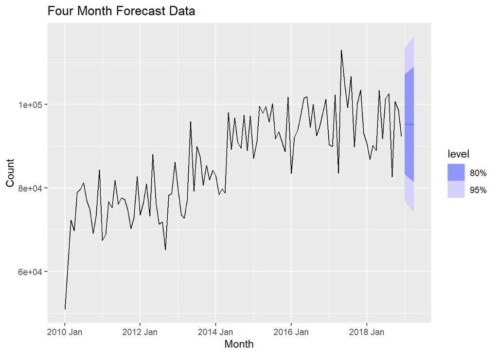

```r
# Plot the forecast data including history starting 2010 Jan.
fourMonthForcastPlot <- ets_fit %>%
  forecast(h = 4) %>%
  autoplot(filter(pigs, Month >= yearmonth('2010 Jan'))) +
  labs(title = 'Four Month Forecast Data')
fourMonthForcastPlot
```

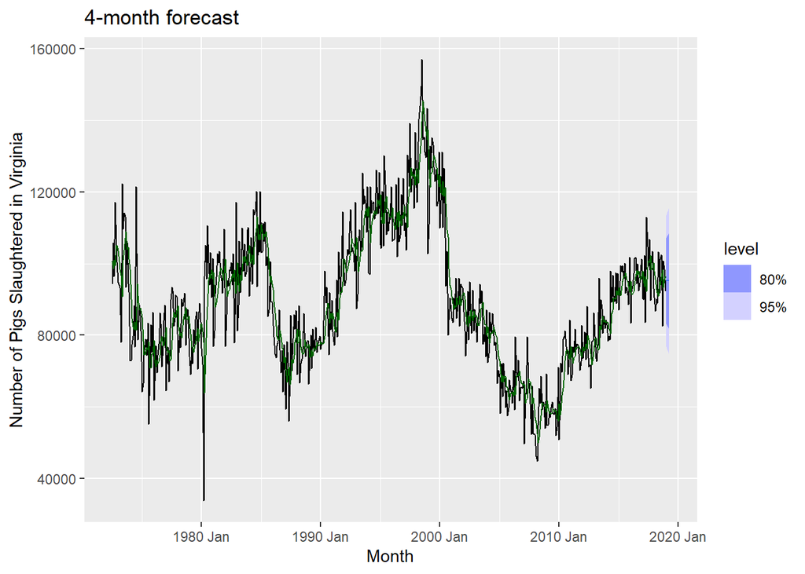

```r
# Plot the forecast data including all history's fitted data.
fourMonthForcast |>
  autoplot (pigs) +
  geom_line (aes (y = .fitted), col = "#006400",
             data = augment (ets_fit)) +
  labs (y = "Number of Pigs Slaughtered in Virginia", title = "4-month forecast") +
  guides (colour = "none")
```

2. Compute a 95% prediction interval for the first forecast using yhat ± 1.96s where s is the standard deviation of the residuals. Compare your interval with the interval produced by R.

Through manual calculations, the forecast range is determined with a lower bound of 76871 and an upper bound of 113502.

The results obtained manually are closely aligned with those computed using R, where the forecast range has a slightly different lower bound of 76854.79 and an upper bound of 113518.3.

```r
# Get the first forecast.
yHat <- fourMonthForcast %>%
  pull(Count) %>%
  head(1)

yHat
```

```
## <distribution[1]>
## [1] N(95187, 8.7e+07)
```

```r
# Get the standard deviation of the residuals.
standardDeviation <- augment(ets_fit) %>%
  pull(.resid) %>%
  sd()

standardDeviation
```

```
## [1] 9344.666
```

```r
# Calculate the lower and upper confidence intervals.
# The 95% confidence interval for the predicted value (yHat) is between 76871 (lower bound) and 113502 (upper bound), assuming a normal distribution of the errors with the specified standard deviation. This interval represents where the true value is likely to fall with 95% confidence.
lowerCi <- yHat - 1.96 * standardDeviation
upperCi <- yHat + 1.96 * standardDeviation
results <- c(lowerCi, upperCi)

names(results) <- c('Lower', 'Upper')
results
```

```
## <distribution[2]>
##              Lower              Upper
##  N(76871, 8.7e+07) N(113502, 8.7e+07)
```

```r
# The interval produced by R
hilo(fourMonthForcast$Count, 95)
```

```
## <hilo[4]>
## [1] [76854.79, 113518.3]95 [75927.17, 114445.9]95 [75042.22, 115330.9]95
## [4] [74194.54, 116178.6]95
```